# HW6: Text Mining

Chenxi Zhu, Teresa Chang, and Tiffany Luo

2023-12-17

The aim of this Markdown is to demonstrate the use of various text analysis tools in R, including text clustering, word clouds and sentiment analysis.

# 3.Results

Here, we have a list of 20 most popular books which we obtain from the Gutenberg project (https://www.gutenberg.org/ebooks/search/?sort_order=downloads). These books are sorted by popularity/number of downloads.

```r
library(wordcloud)
library(text)
library(tm)
library(SnowballC)
library(words)
library(NbClust)
library(stringr)
library(dplyr)
library(syuzhet)
```

## 3.1 Load and preprocess the text of the books from www.gutenberg.org.

```r
# Define the URLs of the text documents
urls <- c(
  "https://www.gutenberg.org/cache/epub/84/pg84.txt",
  "https://www.gutenberg.org/cache/epub/2701/pg2701.txt",
  "https://www.gutenberg.org/cache/epub/46/pg46.txt",
  "https://www.gutenberg.org/cache/epub/1342/pg1342.txt",
  "https://www.gutenberg.org/cache/epub/1513/pg1513.txt",
  "https://www.gutenberg.org/cache/epub/145/pg145.txt",
  "https://www.gutenberg.org/cache/epub/2641/pg2641.txt",
  "https://www.gutenberg.org/cache/epub/100/pg100.txt",
  "https://www.gutenberg.org/cache/epub/37106/pg37106.txt",
  "https://www.gutenberg.org/cache/epub/16389/pg16389.txt",
  "https://www.gutenberg.org/cache/epub/67979/pg67979.txt",
  "https://www.gutenberg.org/cache/epub/394/pg394.txt",
  "https://www.gutenberg.org/cache/epub/6761/pg6761.txt",
  "https://www.gutenberg.org/cache/epub/2160/pg2160.txt",
  "https://www.gutenberg.org/cache/epub/4085/pg4085.txt",
  "https://www.gutenberg.org/cache/epub/6593/pg6593.txt",
  "https://www.gutenberg.org/cache/epub/5197/pg5197.txt",
  "https://www.gutenberg.org/cache/epub/1259/pg1259.txt",
  "https://www.gutenberg.org/cache/epub/31516/pg31516.txt",
  "https://www.gutenberg.org/cache/epub/11/pg11.txt"
)
```

## 3.2 Data Preprocessing

The first thing we want to do is to convert the text in all of these URLS into a Corpus.

```r
# Load and preprocess all text documents
myCorpus <- tm::VCorpus(VectorSource(sapply(urls, readLines)))

# Convert everything to lower case
myCorpus <- tm_map(myCorpus, content_transformer(tolower))
```

We’ll look at lines 830-900 of the first entry (document) in the corpus, which can exclude information about the ebook, and the Table of Contents.

```r
cat(content(myCorpus[[1]])[830:900], sep = "\n")
```

```
## tempest and calm, the silence of winter, and the life and turbulence of
## our alpine summers—she found ample scope for admiration and delight.
## while my companion contemplated with a serious and satisfied spirit the
## magnificent appearances of things, i delighted in investigating their
## causes. the world was to me a secret which i desired to divine.
## curiosity, earnest research to learn the hidden laws of nature,
## gladness akin to rapture, as they were unfolded to me, are among the
## earliest sensations i can remember.
##
## on the birth of a second son, my junior by seven years, my parents gave
## up entirely their wandering life and fixed themselves in their native
## country. we possessed a house in geneva, and a _campagne_ on belrive,
## the eastern shore of the lake, at the distance of rather more than a
## league from the city. we resided principally in the latter, and the
## lives of my parents were passed in considerable seclusion. it was my
## temper to avoid a crowd and to attach myself fervently to a few. i was
## indifferent, therefore, to my school-fellows in general; but i united
## myself in the bonds of the closest friendship to one among them. henry
## clerval was the son of a merchant of geneva. he was a boy of singular
## talent and fancy. he loved enterprise, hardship, and even danger for
## its own sake. he was deeply read in books of chivalry and romance. he
## composed heroic songs and began to write many a tale of enchantment and
## knightly adventure. he tried to make us act plays and to enter into
## masquerades, in which the characters were drawn from the heroes of
## roncesvalles, of the round table of king arthur, and the chivalrous
## train who shed their blood to redeem the holy sepulchre from the hands
## of the infidels.
##
## no human being could have passed a happier childhood than myself. my
## parents were possessed by the very spirit of kindness and indulgence.
## we felt that they were not the tyrants to rule our lot according to
## their caprice, but the agents and creators of all the many delights
## which we enjoyed. when i mingled with other families i distinctly
## discerned how peculiarly fortunate my lot was, and gratitude assisted
## the development of filial love.
##
## my temper was sometimes violent, and my passions vehement; but by some
## law in my temperature they were turned not towards childish pursuits
## but to an eager desire to learn, and not to learn all things
## indiscriminately. i confess that neither the structure of languages,
```

[output cut: 16 more lines]

```
## sullen in my study, rough through the ardour of my nature, but that
## she was there to subdue me to a semblance of her own gentleness. and
## clerval—could aught ill entrench on the noble spirit of clerval? yet
## he might not have been so perfectly humane, so thoughtful in his
## generosity, so full of kindness and tenderness amidst his passion for
## adventurous exploit, had she not unfolded to him the real loveliness of
## beneficence and made the doing good the end and aim of his soaring
## ambition.
##
## i feel exquisite pleasure in dwelling on the recollections of childhood,
## before misfortune had tainted my mind and changed its bright visions of
## extensive usefulness into gloomy and narrow reflections upon self. besides,
## in drawing the picture of my early days, i also record those events which
## led, by insensible steps, to my after tale of misery, for when i would
## account to myself for the birth of that passion which afterwards ruled my
```

Now that we have the data in a corpus, we’ll do some data cleaning, by converting a bunch of special characters (e.g., **@**, **/**, **]**, **$**) to a space and by removing apostrophes.

```r
#     Defining the toSpace function
toSpace <- content_transformer(function(x, pattern) gsub(pattern, " ", x))
#     Defining the remApostrophe function
remApostrophe <- content_transformer(function(x,pattern) gsub(pattern, "", x))
#     Removing special characters
myCorpus <- tm_map(myCorpus, toSpace, "@")
myCorpus <- tm_map(myCorpus, toSpace, "/")
myCorpus <- tm_map(myCorpus, toSpace, "]")
myCorpus <- tm_map(myCorpus, toSpace, "$")
myCorpus <- tm_map(myCorpus, toSpace, "—")
myCorpus <- tm_map(myCorpus, toSpace, "‐")
myCorpus <- tm_map(myCorpus, toSpace, "”")
myCorpus <- tm_map(myCorpus, toSpace, "‘")
myCorpus <- tm_map(myCorpus, toSpace, "“")
myCorpus <- tm_map(myCorpus, toSpace, "‘")
myCorpus <- tm_map(myCorpus, remApostrophe, "’")
```

We’ll then remove numbers and punctuation.

```r
myCorpus <- tm::tm_map(myCorpus, removeNumbers)
myCorpus <- tm_map(myCorpus, removePunctuation)
cat(content(myCorpus[[1]])[830:900], sep = "\n")
```

```
## tempest and calm the silence of winter and the life and turbulence of
## our alpine summers she found ample scope for admiration and delight
## while my companion contemplated with a serious and satisfied spirit the
## magnificent appearances of things i delighted in investigating their
## causes the world was to me a secret which i desired to divine
## curiosity earnest research to learn the hidden laws of nature
## gladness akin to rapture as they were unfolded to me are among the
## earliest sensations i can remember
##
## on the birth of a second son my junior by seven years my parents gave
## up entirely their wandering life and fixed themselves in their native
## country we possessed a house in geneva and a campagne on belrive
## the eastern shore of the lake at the distance of rather more than a
## league from the city we resided principally in the latter and the
## lives of my parents were passed in considerable seclusion it was my
## temper to avoid a crowd and to attach myself fervently to a few i was
## indifferent therefore to my schoolfellows in general but i united
## myself in the bonds of the closest friendship to one among them henry
## clerval was the son of a merchant of geneva he was a boy of singular
## talent and fancy he loved enterprise hardship and even danger for
## its own sake he was deeply read in books of chivalry and romance he
## composed heroic songs and began to write many a tale of enchantment and
## knightly adventure he tried to make us act plays and to enter into
## masquerades in which the characters were drawn from the heroes of
## roncesvalles of the round table of king arthur and the chivalrous
## train who shed their blood to redeem the holy sepulchre from the hands
## of the infidels
##
## no human being could have passed a happier childhood than myself my
## parents were possessed by the very spirit of kindness and indulgence
## we felt that they were not the tyrants to rule our lot according to
## their caprice but the agents and creators of all the many delights
## which we enjoyed when i mingled with other families i distinctly
## discerned how peculiarly fortunate my lot was and gratitude assisted
## the development of filial love
##
## my temper was sometimes violent and my passions vehement but by some
## law in my temperature they were turned not towards childish pursuits
## but to an eager desire to learn and not to learn all things
## indiscriminately i confess that neither the structure of languages
```

[output cut: 16 more lines]

```
## sullen in my study rough through the ardour of my nature but that
## she was there to subdue me to a semblance of her own gentleness and
## clerval could aught ill entrench on the noble spirit of clerval yet
## he might not have been so perfectly humane so thoughtful in his
## generosity so full of kindness and tenderness amidst his passion for
## adventurous exploit had she not unfolded to him the real loveliness of
## beneficence and made the doing good the end and aim of his soaring
## ambition
##
## i feel exquisite pleasure in dwelling on the recollections of childhood
## before misfortune had tainted my mind and changed its bright visions of
## extensive usefulness into gloomy and narrow reflections upon self besides
## in drawing the picture of my early days i also record those events which
## led by insensible steps to my after tale of misery for when i would
## account to myself for the birth of that passion which afterwards ruled my
```

We look at a list of English stop words (e.g., *a*, *to*) that we can remove from the documents. Stop words are frequent terms that often don’t provide a lot of useful information.

```r
stopwords("english")
```

```
##   [1] "i"          "me"         "my"         "myself"     "we"
##   [6] "our"        "ours"       "ourselves"  "you"        "your"
##  [11] "yours"      "yourself"   "yourselves" "he"         "him"
##  [16] "his"        "himself"    "she"        "her"        "hers"
##  [21] "herself"    "it"         "its"        "itself"     "they"
##  [26] "them"       "their"      "theirs"     "themselves" "what"
##  [31] "which"      "who"        "whom"       "this"       "that"
##  [36] "these"      "those"      "am"         "is"         "are"
##  [41] "was"        "were"       "be"         "been"       "being"
##  [46] "have"       "has"        "had"        "having"     "do"
##  [51] "does"       "did"        "doing"      "would"      "should"
##  [56] "could"      "ought"      "i'm"        "you're"     "he's"
##  [61] "she's"      "it's"       "we're"      "they're"    "i've"
##  [66] "you've"     "we've"      "they've"    "i'd"        "you'd"
##  [71] "he'd"       "she'd"      "we'd"       "they'd"     "i'll"
```

[output cut: 20 more lines]

```r
myCorpus <- tm_map(myCorpus, removeWords, stopwords("english"))
cat(content(myCorpus[[1]])[830:900], sep = "\n")
```

```
## tempest  calm  silence  winter   life  turbulence
##  alpine summers  found ample scope  admiration  delight
##   companion contemplated   serious  satisfied spirit
## magnificent appearances  things  delighted  investigating
## causes  world     secret   desired  divine
## curiosity earnest research  learn  hidden laws  nature
## gladness akin  rapture    unfolded    among
## earliest sensations  can remember
##
##   birth   second son  junior  seven years  parents gave
##  entirely  wandering life  fixed    native
## country  possessed  house  geneva   campagne  belrive
##  eastern shore   lake   distance  rather
## league   city  resided principally   latter
## lives   parents  passed  considerable seclusion
## temper  avoid  crowd   attach  fervently
## indifferent therefore   schoolfellows  general   united
##    bonds   closest friendship  one among  henry
## clerval   son   merchant  geneva    boy  singular
## talent  fancy  loved enterprise hardship  even danger
##   sake   deeply read  books  chivalry  romance
## composed heroic songs  began  write many  tale  enchantment
## knightly adventure  tried  make us act plays   enter
## masquerades    characters  drawn   heroes
## roncesvalles   round table  king arthur   chivalrous
## train  shed  blood  redeem  holy sepulchre   hands
##   infidels
##
##  human    passed  happier childhood
## parents  possessed    spirit  kindness  indulgence
##  felt      tyrants  rule  lot according
##  caprice   agents  creators    many delights
##   enjoyed   mingled   families  distinctly
## discerned  peculiarly fortunate  lot   gratitude assisted
##  development  filial love
##
##  temper  sometimes violent   passions vehement
## law   temperature   turned  towards childish pursuits
##    eager desire  learn    learn  things
## indiscriminately  confess  neither  structure  languages
```

[output cut: 16 more lines]

```
## sullen   study rough   ardour   nature
##     subdue    semblance    gentleness
## clerval  aught ill entrench   noble spirit  clerval yet
##  might     perfectly humane  thoughtful
## generosity  full  kindness  tenderness amidst  passion
## adventurous exploit    unfolded    real loveliness
## beneficence  made   good  end  aim   soaring
## ambition
##
##  feel exquisite pleasure  dwelling   recollections  childhood
##  misfortune  tainted  mind  changed  bright visions
## extensive usefulness  gloomy  narrow reflections upon self besides
##  drawing  picture   early days  also record  events
## led  insensible steps    tale  misery
## account     birth   passion  afterwards ruled
```

We can also remove additional (i.e., self-defined) stop words, such as *ebook* that appear in the first few lines of the text.

```r
myCorpus <- tm_map(myCorpus, removeWords,c("ebook", "author", "translators",
                                           "start wwwgutenbergorg", "gutenberg", "chapter", "book", "contents"))
cat(content(myCorpus[[1]])[830:900], sep = "\n")
```

```
## tempest  calm  silence  winter   life  turbulence
##  alpine summers  found ample scope  admiration  delight
##   companion contemplated   serious  satisfied spirit
## magnificent appearances  things  delighted  investigating
## causes  world     secret   desired  divine
## curiosity earnest research  learn  hidden laws  nature
## gladness akin  rapture    unfolded    among
## earliest sensations  can remember
##
##   birth   second son  junior  seven years  parents gave
##  entirely  wandering life  fixed    native
## country  possessed  house  geneva   campagne  belrive
##  eastern shore   lake   distance  rather
## league   city  resided principally   latter
## lives   parents  passed  considerable seclusion
## temper  avoid  crowd   attach  fervently
## indifferent therefore   schoolfellows  general   united
##    bonds   closest friendship  one among  henry
## clerval   son   merchant  geneva    boy  singular
## talent  fancy  loved enterprise hardship  even danger
##   sake   deeply read  books  chivalry  romance
## composed heroic songs  began  write many  tale  enchantment
## knightly adventure  tried  make us act plays   enter
## masquerades    characters  drawn   heroes
## roncesvalles   round table  king arthur   chivalrous
## train  shed  blood  redeem  holy sepulchre   hands
##   infidels
##
##  human    passed  happier childhood
## parents  possessed    spirit  kindness  indulgence
##  felt      tyrants  rule  lot according
##  caprice   agents  creators    many delights
##   enjoyed   mingled   families  distinctly
## discerned  peculiarly fortunate  lot   gratitude assisted
##  development  filial love
##
##  temper  sometimes violent   passions vehement
## law   temperature   turned  towards childish pursuits
##    eager desire  learn    learn  things
## indiscriminately  confess  neither  structure  languages
```

[output cut: 16 more lines]

```
## sullen   study rough   ardour   nature
##     subdue    semblance    gentleness
## clerval  aught ill entrench   noble spirit  clerval yet
##  might     perfectly humane  thoughtful
## generosity  full  kindness  tenderness amidst  passion
## adventurous exploit    unfolded    real loveliness
## beneficence  made   good  end  aim   soaring
## ambition
##
##  feel exquisite pleasure  dwelling   recollections  childhood
##  misfortune  tainted  mind  changed  bright visions
## extensive usefulness  gloomy  narrow reflections upon self besides
##  drawing  picture   early days  also record  events
## led  insensible steps    tale  misery
## account     birth   passion  afterwards ruled
```

Lastly, We can play around with stemming. This removes common word suffixes and endings like *es*, *ed*, *ing*, etc. Alternatively, there is lemmatization, which groups together different inflected forms of the same word.

```r
myCorpus <- tm_map(myCorpus, stemDocument)
cat(content(myCorpus[[1]])[830:900], sep = "\n")
```

[output not shown]

## 3.3 Term Document Matrix

The next step is to create a term document matrix (TDM). A TDM is a representation of how frequently different terms (shown in rows) appear in each of the documents (shown in columns). The transpose of the TDM is the document term matrix (DTM), where the rows and columns are switched.

```r
tdm <- TermDocumentMatrix(myCorpus)
tm::inspect(tdm)
```

```
## <<TermDocumentMatrix (terms: 63455, documents: 20)>>
## Non-/sparse entries: 207109/1061991
## Sparsity           : 84%
## Maximal term length: 43
## Weighting          : term frequency (tf)
## Sample             :
##        Docs
## Terms    13  14  15   16  17   18   2    6    8   9
##   good  171 237 320  675 183  320 198  538 2975 412
##   man   135 170 218  684 254  711 448  643 1921 145
##   now   200 191 154 1018 399  470 782  632 3030 407
##   one   267 344 443  947 591  973 906  821 1970 880
##   said  136 278 316  944 108 2385 305 2293  424 840
##   shall 134 221 126  506  28  457  99  330 3860 257
##   thou   36  13  34  111   5   82 269    7 5866  21
##   upon  786 463 668  728 365  263 567  135 1866 191
##   well  136 175 268  675 170  630 231  482 2644 371
##   will  256 391 225 1337  43 1067 398 1269 5310 513
```

We convert the TDM to a matrix that we call `m`. Each of the rows in `m` corresponds to each of the unique terms (words) that appears in the documents, and each of the columns corresponds to each document.

```r
m<- as.matrix(tdm)
dim(m)
```

```
## [1] 63455    20
```

```r
rownames(m) <- tdm$dimnames$Terms
colnames(m) <- c("Frankenstein", "Moby Dick", "A Christmas Carol in Prose", "Pride and Prejudice", "Romeo and Juliet", "Middlemarch", "A Room with a View",
"The Complete Works of William Shakespeare", "Little Women", "The Enchanted April", "The Blue Castle", "Cranford", "The Adventures of Ferdinand Count Fathom", "The Expedition of Humphry Clinker", "The Adventures of Roderick Random", "History of Tom Jones, a Foundling", "My Life — Volume 1", "Twenty years after", "The Eyes Have It", "Alice's Adventures in Wonderland")
head(m)
```

```
##          Docs
## Terms     Frankenstein Moby Dick A Christmas Carol in Prose Pride and Prejudice
##   ·pride             0         0                          0                   1
##   aaron              0         0                          0                   0
##   aarons             0         0                          0                   0
##   aback              0         2                          0                   0
##   abaddon            0         0                          0                   0
##   abaft              0         2                          0                   0
##          Docs
## Terms     Romeo and Juliet Middlemarch A Room with a View
##   ·pride                 0           0                  0
##   aaron                  0           0                  0
##   aarons                 0           0                  0
##   aback                  0           0                  0
##   abaddon                0           0                  0
##   abaft                  0           0                  0
##          Docs
## Terms     The Complete Works of William Shakespeare Little Women
##   ·pride                                          0            0
##   aaron                                          98            0
##   aarons                                          1            0
##   aback                                           0            1
##   abaddon                                         0            0
##   abaft                                           0            0
##          Docs
## Terms     The Enchanted April The Blue Castle Cranford
##   ·pride                    0               0        0
##   aaron                     0               1        0
##   aarons                    0               0        0
##   aback                     4               0        1
##   abaddon                   0               0        1
##   abaft                     0               0        0
##          Docs
## Terms     The Adventures of Ferdinand Count Fathom
##   ·pride                                         0
##   aaron                                          0
##   aarons                                         2
##   aback                                          0
##   abaddon                                        0
##   abaft                                          0
```

[output cut: 9 more lines]

```
## Terms     History of Tom Jones, a Foundling My Life — Volume 1
##   ·pride                                  0                  0
##   aaron                                   0                  0
##   aarons                                  0                  0
##   aback                                   0                  2
##   abaddon                                 0                  0
##   abaft                                   0                  0
##          Docs
## Terms     Twenty years after The Eyes Have It Alice's Adventures in Wonderland
##   ·pride                   0                0                                0
##   aaron                    0                0                                0
##   aarons                   0                0                                0
##   aback                    0                0                                0
##   abaddon                  0                0                                0
##   abaft                    0                0                                0
```

We filter our data to include only those words that are actually in the Scrabble Dictionary.

```r
dictionary <- as.character(words::words$word)
row_names <- rownames(m)
in_dictionary <- row_names %in% dictionary
remove <- as.character(row_names[!in_dictionary])

#Since the data are so large, if we try to remove all words at once, we get an error. So we will remove them in chunks of 1000.

num_observations <- as.numeric(length(remove))  # Total number of observations
chunk_size <- 1000                              # Number of observations to display at a time

for (i in seq(1, num_observations, chunk_size)) {
  start <- i
  end <- i + chunk_size - 1
  end <- ifelse(end > num_observations, num_observations, end)
  myCorpus <- tm_map(myCorpus, removeWords, remove[start:end])
}
```

We look at the terms that were dropped in myCorpus – these are all the words that aren’t in the Scrabble Dictionary

```r
cat(content(myCorpus[[1]])[980:1000], sep = "\n")
```

```
## advanced  behind  mountains  jura   thunder burst
##  frightful loudness  various quarters   heavens  remained
##   storm lasted watching  progress  curiosity  delight
##   stood   door   sudden  beheld  stream  fire issue
## old  beautiful oak  stood  twenty yards   house
## soon   dazzling light vanished  oak  disappeared  nothing
## remained   blasted stump   visited   next morning  found
##  tree shattered   singular manner    splintered
## shock  entirely reduced  thin ribbons  wood  never beheld
## anything  utterly destroyed
##
##      unacquainted    obvious laws
## electricity   occasion  man  great research  natural
## philosophy   us  excited   catastrophe  entered
##  explanation   theory    formed   subject
## electricity  galvanism     new  astonishing
##    said threw greatly   shade
##      lords   imagination
##  fatality  overthrow   men disinclined   pursue
## accustomed studies  seemed     nothing    ever
##  known     long engaged  attention suddenly grew
```

## 3.4 Document Term Matrix

Now that `myCorpus` has had all the words that aren’t in the dictionary removed, we convert it to a document term matrix (DTM). This is the format that we actually want - where the documents are rows, and terms are columns.

```r
dtm_cleaned <- DocumentTermMatrix(myCorpus)
tm::inspect(dtm_cleaned)
```

```
## <<DocumentTermMatrix (documents: 20, terms: 37442)>>
## Non-/sparse entries: 174081/574759
## Sparsity           : 77%
## Maximal term length: 15
## Weighting          : term frequency (tf)
## Sample             :
##     Terms
## Docs good  man  now  one said shall thou upon well will
##   13  171  135  200  267  136   134   36  786  136  256
##   14  237  170  191  344  278   221   13  463  175  391
##   15  320  218  154  443  316   126   34  668  268  225
##   16  675  684 1018  947  944   506  111  728  675 1337
##   17  183  254  399  591  108    28    5  365  170   43
##   18  320  711  470  973 2385   457   82  263  630 1067
##   2   198  448  782  906  305    99  269  567  231  398
##   6   538  643  632  821 2293   330    7  135  482 1269
##   8  2975 1921 3030 1970  424  3860 5866 1866 2644 5310
##   9   412  145  407  880  840   257   21  191  371  513
```

As earlier, we convert the DTM to a matrix.

```r
m <- as.matrix(dtm_cleaned)
dim(m)
```

```
## [1]    20 37442
```

```r
colnames(m) <- dtm_cleaned$dimnames$Terms
rownames(m) <- c("Frankenstein", "Moby Dick", "A Christmas Carol in Prose", "Pride and Prejudice", "Romeo and Juliet", "Middlemarch", "A Room with a View",
"The Complete Works of William Shakespeare", "Little Women", "The Enchanted April", "The Blue Castle", "Cranford", "The Adventures of Ferdinand Count Fathom", "The Expedition of Humphry Clinker", "The Adventures of Roderick Random", "History of Tom Jones, a Foundling", "My Life — Volume 1", "Twenty years after", "The Eyes Have It", "Alice's Adventures in Wonderland")
```

We look at the term distribution. The histogram and tabulation can show us the distribution of term frequency across all terms. We can see that there are a lot of terms that appear only a few times, while some others appear thousands of times. The word cloud shows us the terms that appear the most, such that higher frequency is indicated by a larger font.

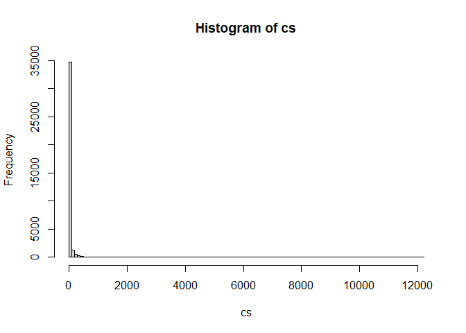

```r
cs <- as.matrix(colSums(m))             #How many times each term appears across all documents (texts)
rownames(cs) <- dtm_cleaned$dimnames$Terms

hist(cs, breaks=100)                    #histograms/tabulations/word cloud of total term appearance
```

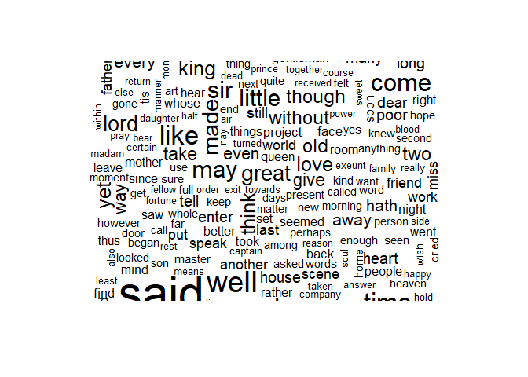

```r
tab <- as.matrix(table(cs))
wordcloud(myCorpus, min.freq=1000)
```

## 3.5 Text Clustering

In our preparation for cluster analysis, we remove all variables where the column sum is less than 10,000 (i.e., if the term appears less than 10,000 times in all documents). We are only doing it here so that we have a reasonable number of variables to include in the cluster analysis for the sake of this example.

```r
variables_to_remove <- cs < 10000

# Subset matrix frame, excluding those variables
m_subset <- m[, !variables_to_remove]
```

We do some additional data preparation for the cluster analysis.

```r
#Some books are longer, others are shorter. We divide the frequencies by the total number of words (after processing) in each book.
m_fin <- m_subset/rowSums(m)

#Let's scale (normalize) each of the variables (relative frequency)
m_scale <- scale(m_fin)
```

Before performing the k-means analysis on the scaled (normalized) relative frequencies of words, we need to identify the optimal number of clusters based on the result of NbClust approach.

```r
#NbClust approach
set.seed(1234)
nc <- NbClust(m_scale, min.nc=2, max.nc=15, method="kmeans", index="all")
```

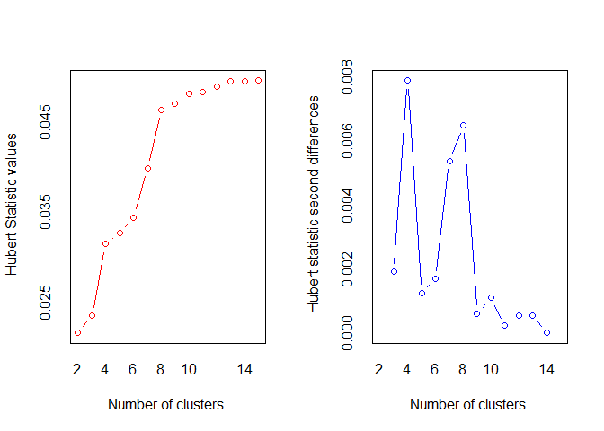

```
## *** : The Hubert index is a graphical method of determining the number of clusters.
##                 In the plot of Hubert index, we seek a significant knee that corresponds to a
##                 significant increase of the value of the measure i.e the significant peak in Hubert
##                 index second differences plot.
##
```

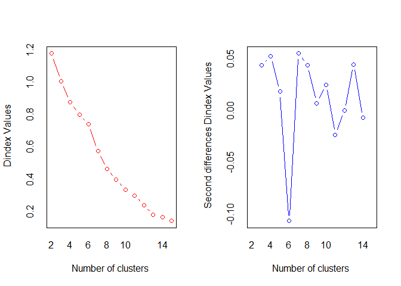

```
## *** : The D index is a graphical method of determining the number of clusters.
##                 In the plot of D index, we seek a significant knee (the significant peak in Dindex
##                 second differences plot) that corresponds to a significant increase of the value of
##                 the measure.
##
## * Among all indices:
## * 4 proposed 2 as the best number of clusters
## * 3 proposed 3 as the best number of clusters
## * 3 proposed 4 as the best number of clusters
## * 1 proposed 8 as the best number of clusters
## * 2 proposed 12 as the best number of clusters
## * 7 proposed 13 as the best number of clusters
## * 3 proposed 15 as the best number of clusters
##
##                    ***** Conclusion *****
##
## * According to the majority rule, the best number of clusters is  13
##
##
```

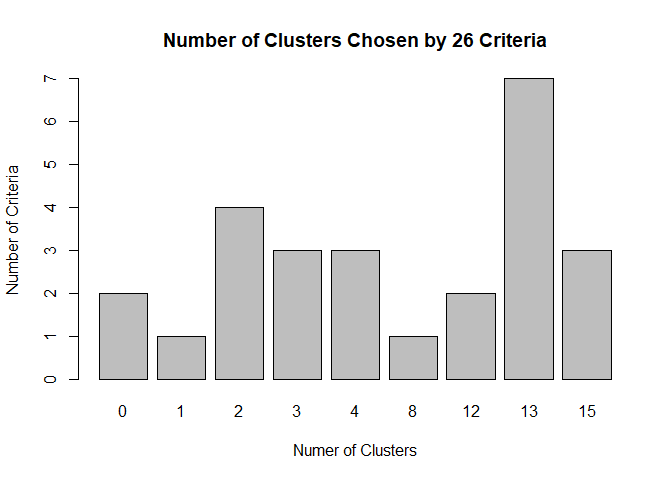

```r
#table(nc$Best.n[1,])
par(mfrow=c(1,1))
barplot(table(nc$Best.n[1,]),
        xlab="Numer of Clusters", ylab="Number of Criteria",
        main="Number of Clusters Chosen by 26 Criteria")
```

```r
k_means_results <- kmeans(m_scale, 3, 30)
```

```r
k_means_results$cluster
```

```
##                              Frankenstein
##                                         2
##                                 Moby Dick
##                                         1
##                A Christmas Carol in Prose
##                                         1
##                       Pride and Prejudice
##                                         2
##                          Romeo and Juliet
##                                         2
##                               Middlemarch
##                                         3
##                        A Room with a View
##                                         3
## The Complete Works of William Shakespeare
##                                         2
##                              Little Women
##                                         1
##                       The Enchanted April
##                                         1
##                           The Blue Castle
##                                         1
##                                  Cranford
##                                         1
##  The Adventures of Ferdinand Count Fathom
##                                         2
##         The Expedition of Humphry Clinker
##                                         2
##         The Adventures of Roderick Random
##                                         2
##         History of Tom Jones, a Foundling
##                                         2
##                        My Life — Volume 1
##                                         1
##                        Twenty years after
##                                         3
##                          The Eyes Have It
##                                         2
##          Alice's Adventures in Wonderland
##                                         3
```

```r
k_means_results$size
```

```
## [1] 7 9 4
```

Finally, we look at the number of times each of the terms appears in each cluster. Ultimately, we see that certain terms have different frequencies in the clusters.

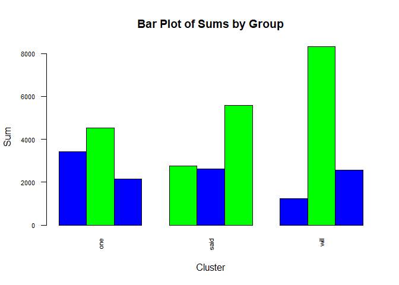

```r
word_totals_by_cluster <- round(aggregate(m_subset, by=list(cluster=k_means_results$cluster), sum),1)

#plot the results
#Decrease font size and rotate x-axis labels vertically
par(cex.axis = 0.7)  # Adjust the font size
par(las = 2)        # Rotate labels vertically

barplot(as.matrix(word_totals_by_cluster[-1]),
        beside = TRUE,
        col = c("blue", "green"),
        legend.text = TRUE,
        args.legend = list(x = "topright"))

# Add labels to the x-axis and y-axis. Here, the first cluster is in blue and the second one is in green.
title(xlab = "Cluster")
title(ylab = "Sum")

# Add a title to the plot
title(main = "Bar Plot of Sums by Group")
```

## 3.6 Sentiment Analysis

A sentiment lexicon, also known as a sentiment dictionary, is a collection of words or phrases annotated with sentiment polarity information. It associates each word or phrase with a sentiment score indicating its positive, negative, or neutral sentiment. Sentiment lexicons are commonly used in sentiment analysis tasks to determine the sentiment or emotional tone expressed in text.

We use sentiment analysis to examine the sentiment in an entire body of text for the 20 most popular books. This is often done by aggregating sentiment scores of all the words in the text. One issue is that for longer texts, the positive and negative terms often tend to wash each other out. Therefore, shorter texts of a few sentences or paragraphs work well.

Here, we will use nrc as our sentiment lexicon.We take the first book in our data, Frankenstein, which is the first row of the matrix `m`. The `get_nrc_sentiment` command obtains the sentiment score for each word in Frankenstein that wasn’t removed in the cleaning process above.

```r
nrc <- syuzhet::get_sentiment_dictionary(dictionary="nrc")
head(nrc, n=20L)
```

```
##       lang           word sentiment value
## 1  english           abba  positive     1
## 2  english        ability  positive     1
## 3  english abovementioned  positive     1
## 4  english       absolute  positive     1
## 5  english     absolution  positive     1
## 6  english       absorbed  positive     1
## 7  english      abundance  positive     1
## 8  english       abundant  positive     1
## 9  english       academic  positive     1
## 10 english        academy  positive     1
## 11 english     acceptable  positive     1
## 12 english     acceptance  positive     1
## 13 english     accessible  positive     1
## 14 english       accolade  positive     1
## 15 english  accommodation  positive     1
## 16 english  accompaniment  positive     1
## 17 english     accomplish  positive     1
## 18 english   accomplished  positive     1
## 19 english accomplishment  positive     1
## 20 english         accord  positive     1
```

```r
afinn <- syuzhet::get_sentiment_dictionary(dictionary="afinn")
head(afinn, n=20L)
```

```
##          word value
## 1     abandon    -2
## 2   abandoned    -2
## 3    abandons    -2
## 4    abducted    -2
## 5   abduction    -2
## 6  abductions    -2
## 7       abhor    -3
## 8    abhorred    -3
## 9   abhorrent    -3
## 10     abhors    -3
## 11  abilities     2
## 12    ability     2
## 13     aboard     1
## 14    aborted    -1
## 15     aborts    -1
## 16   absentee    -1
## 17  absentees    -1
## 18    absolve     2
## 19   absolved     2
## 20   absolves     2
```

```r
bing <- syuzhet::get_sentiment_dictionary(dictionary="bing")
head(bing, n=20L)
```

```
##               word value
## 1               a+     1
## 2           abound     1
## 3          abounds     1
## 4        abundance     1
## 5         abundant     1
## 6       accessable     1
## 7       accessible     1
## 8          acclaim     1
## 9        acclaimed     1
## 10     acclamation     1
## 11        accolade     1
## 12       accolades     1
## 13   accommodative     1
## 14    accomodative     1
## 15      accomplish     1
## 16    accomplished     1
## 17  accomplishment     1
## 18 accomplishments     1
## 19        accurate     1
## 20      accurately     1
```

```r
syuzhet <- syuzhet::get_sentiment_dictionary(dictionary="syuzhet")
head(syuzhet, n=20L)
```

```
##           word value
## 1      abandon -0.75
## 2    abandoned -0.50
## 3    abandoner -0.25
## 4  abandonment -0.25
## 5     abandons -1.00
## 6     abducted -1.00
## 7    abduction -0.50
## 8   abductions -1.00
## 9     aberrant -0.60
## 10  aberration -0.80
## 11       abhor -0.50
## 12    abhorred -1.00
## 13   abhorrent -0.50
## 14      abhors -1.00
## 15   abilities  0.60
## 16     ability  0.50
## 17      abject -1.00
## 18      ablaze -0.25
## 19    abnormal -0.50
## 20      aboard  0.25
```

```r
get_nrc_sentiment("gorgeous")
```

```
##   anger anticipation disgust fear joy sadness surprise trust negative positive
## 1     0            0       0    0   1       0        0     0        0        1
```

```r
Frankenstein <- as.data.frame(m[1,])
Frankenstein$Term <- as.vector(rownames(Frankenstein))
colnames(Frankenstein)[1] = "Term_Frequency"
rownames(Frankenstein) <- 1:nrow(Frankenstein)

nrc_sentiment <- get_nrc_sentiment(Frankenstein$Term)
```

We combine the original data frame and the sentiment counts.

```r
Frankenstein_Sentiment <- cbind(Frankenstein, nrc_sentiment)
```

We multiply the sentiment by the frequency of the term.

```r
head(Frankenstein)
```

```
##   Term_Frequency      Term
## 1              0    ·pride
## 2              0     aback
## 3              0     abaft
## 4              2   abandon
## 5              3 abandoned
## 6              0 abandoner
```

```r
# Select the columns to be multiplied (last ten columns)
cols_to_multiply <- names(Frankenstein_Sentiment)[3:12]


# Multiply the last ten columns (sentiments) by the first column (Term_Frequency)
Frankenstein_Sentiment[, cols_to_multiply] <- Frankenstein_Sentiment[, cols_to_multiply] * Frankenstein_Sentiment$Term_Frequency
```

We’ll see the total prevalence of each sentiment in the text by summing each column and creating a bar plot

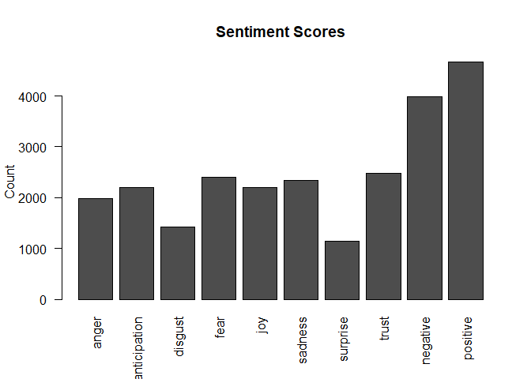

```r
Frankenstein_Sentiment_Total <- t(as.matrix(colSums(Frankenstein_Sentiment[,-1:-2])))
barplot(Frankenstein_Sentiment_Total, las=2, ylab='Count', main='Sentiment Scores')
```

From the plot above, we can see that the number of words with positive sentiments are more than the number of words with negative sentiments. Note that We’re using Frankenstein as an example for the sentiment analysis, and this process can be done for each of the books to find out their word sentiment distribution.

We can also try other lexicons in addition to nrc. Specifically, we will use the `get_sentiment` command to get the scores for each of the terms using each dictionary.

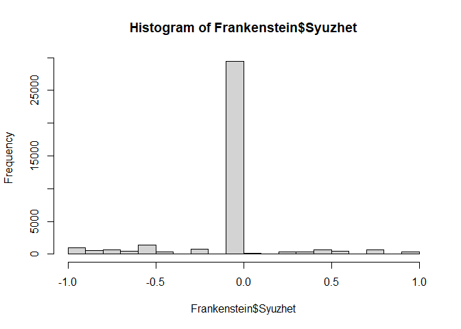

```r
Frankenstein$Syuzhet <- as.matrix(get_sentiment(Frankenstein$Term, method="syuzhet"))
hist(Frankenstein$Syuzhet)
```

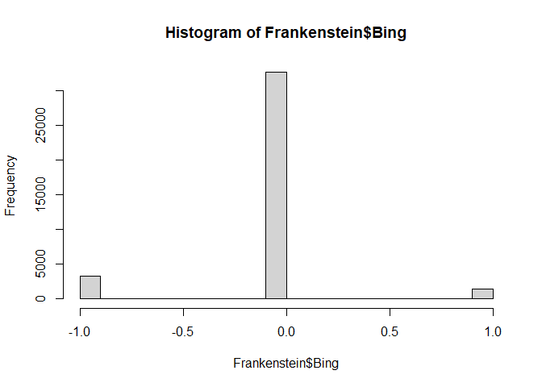

```r
Frankenstein$Bing <- as.matrix(get_sentiment(Frankenstein$Term, method="bing"))
hist(Frankenstein$Bing)
```

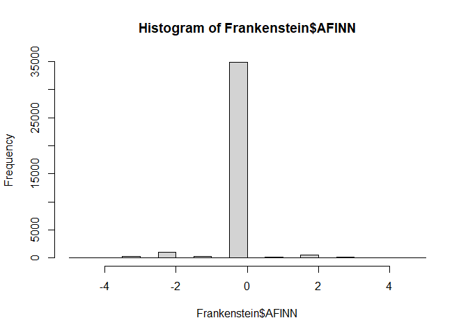

```r
Frankenstein$AFINN <- as.matrix(get_sentiment(Frankenstein$Term, method="afinn"))
hist(Frankenstein$AFINN)
```

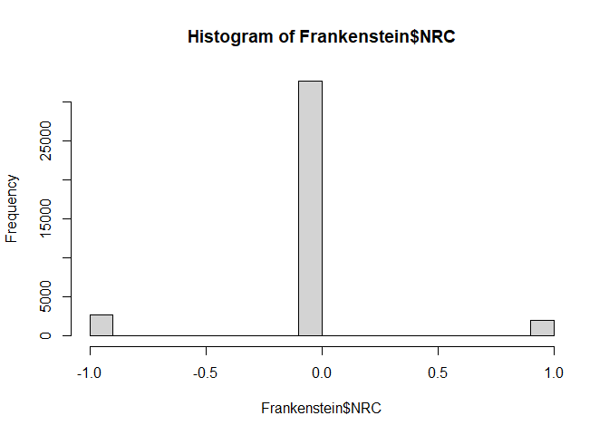

```r
Frankenstein$NRC <- as.matrix(get_sentiment(Frankenstein$Term, method="nrc"))   #There are Negative and Positive sentiments in the NRC output above.
hist(Frankenstein$NRC)
```

We can compare the results from the different lexicons by assigning a value of -1 to all terms that have a negative sentiment, 0 to all terms that have a neutral sentiment, and 1 to all terms that have a positive sentiment.

```r
sentiment_columns <- Frankenstein[ , 3:6]
sentiment_columns <- data.frame(lapply(sentiment_columns, sign))
sentiment_columns <- data.frame(lapply(sentiment_columns, as.factor))
```

We have the prevalence of *unique* negative, neutral terms (here, we are talking about *unique* terms because we are not weighing them by how often they appear in the document).

```r
#Raw frequencies
sapply(sentiment_columns, function(x) if("factor" %in% class(x)) {table(x)})
```

```
##    Syuzhet  Bing AFINN   NRC
## -1    5125  3306  1654  2745
## 0    29381 32656 34828 32677
## 1     2936  1480   960  2020
```

```r
#Proportions
sapply(sentiment_columns, function(x) if("factor" %in% class(x)) {prop.table(table(x))})
```

```
##       Syuzhet       Bing      AFINN        NRC
## -1 0.13687837 0.08829657 0.04417499 0.07331339
## 0  0.78470701 0.87217563 0.93018535 0.87273650
## 1  0.07841461 0.03952780 0.02563966 0.05395011
```

We can see that in general, most of the terms are neutral, with about 3-8% of terms being positive and 4-13% of the terms being negative, depending on which lexicon we use.

# 4. Discussion

Going beyond word frequency, investigating the sentiment distribution across different chapters or different novels may help to identify the tone of the narratives. There might be specific chapters or novels associated with more positive or negative sentiments. This could provide a understanding of the novel’s themes and plot development.

For future analysis, we can use Frankenstein as an example work of Gothic literature, and explore similar Gothic literature to find whether there are specific words associated with the Gothic genre in general. This can help to identify the key words in the genre, and link with the cultural and historical context. In addition, we can apply this method to more genres and find their genre key words.